# What if - technical paper

[What if](https://healthpolicy.github.io/nhs_whatif/) is a data visualisation designed for general people who are not necessarily familiar with healthcare in England or data analysis, explaining simplification of some visuals which is intended for easier understanding of the story. This may have brought some subtleties that sacrifice technicality - such as definition of each variable, source of raw data, or how they were processed for visualisation. In that capacity, the objective of this technical paper is to complete the potential incompleteness from the perspective of technicality.

If you have any question or feedback, please let me know (ocho@healthpolicy.com.au).

NOTE: As of 02 Mar 2020, this document is still work in progress.

# Importing data

## Source

The code snippet below (hidden) shows how the source of each dataset was identified. It is summarised in the following table.

```r
raw_data_source <- list(
  imd_lad = tibble(
    description = "Index of multiple deprivation (IMD), local authority district",
    source = "GOV.UK",
    year = "",
    page_url = "https://www.gov.uk/government/statistics/english-indices-of-deprivation-2019",
    download_url = "https://assets.publishing.service.gov.uk/government/uploads/system/uploads/attachment_data/file/833995/File_10_-_IoD2019_Local_Authority_District_Summaries__lower-tier__.xlsx"
  ),
  imd_ccg = tibble(
    description = "Index of multiple deprivation (IMD), clinical commissioning group",
    source = "GOV.UK",
    year = "",
    page_url = "https://www.gov.uk/government/statistics/english-indices-of-deprivation-2019",
    download_url = "https://assets.publishing.service.gov.uk/government/uploads/system/uploads/attachment_data/file/834003/File_13_-_IoD2019_Clinical_Commissioning_Group__CCG__Summaries.xlsx"
  ),
  imd_lsoa = tibble(
    description = "Index of multiple deprivation (IMD), Lower layer Super Output Area",
    source = "GOV.UK",
    year = "",
    page_url = "https://www.gov.uk/government/statistics/english-indices-of-deprivation-2019",
    download_url = "https://assets.publishing.service.gov.uk/government/uploads/system/uploads/attachment_data/file/845345/File_7_-_All_IoD2019_Scores__Ranks__Deciles_and_Population_Denominators_3.csv"
  ),
  pop_lsoa = tibble(
    description = "Population estimates, Lower layer Super Output Area",
    source = "ONS",
    year = "",
    page_url = "https://www.ons.gov.uk/peoplepopulationandcommunity/populationandmigration/populationestimates/datasets/lowersuperoutputareamidyearpopulationestimates",
    download_url = "https://www.ons.gov.uk/file?uri=%2fpeoplepopulationandcommunity%2fpopulationandmigration%2fpopulationestimates%2fdatasets%2flowersuperoutputareamidyearpopulationestimates%2fmid2018sape21dt1a/sape21dt1amid2018on2019lalsoasyoaestimatesformatted.zip"
  ),
  pop_lad = tibble(
    description = "Population, Local Authority District",
    source = "ONS",
    year = "",
    page_url = "https://www.ons.gov.uk/peoplepopulationandcommunity/populationandmigration/populationestimates/datasets/populationestimatesforukenglandandwalesscotlandandnorthernireland",
    download_url = "https://www.ons.gov.uk/file?uri=/peoplepopulationandcommunity/populationandmigration/populat….xls"
  ),
  hd_mort = tibble(
    description = "Mortality from coronary heart disease: directly standardised rate, <75 years, 3-year average, MFP",
    source = "NHS",
    year = "2015-2017",
    page_url = "https://digital.nhs.uk/data-and-information/publications/clinical-indicators/compendium-of-population-health-indicators/compendium-mortality/current/mortality-from-coronary-heart-disease/mortality-from-coronary-heart-disease-directly-standardised-rate-lt75-years-3-year-average-mfp",
    download_url = "https://files.digital.nhs.uk/F8/C91387/09A_054DR0074_D.csv"
  ),
  chd_emer_admit = tibble(
    description = "CHD emergency admission",
    source = "LG inform",
    year = "2011/12-2015/16",
    page_url = "https://lginform.local.gov.uk/reports/lgastandard?mod-metric=3177&mod-area=E92000001&mod-group=AllRegions_England&mod-type=namedComparisonGroup",
    download_url = "https://lginform.local.gov.uk/reports/shared/V265384F4A30624259316E38357A416F4B54356D2B…"
  ),
  chd_elec_admit = tibble(
    description = "CHD elective admission",
    source = "LG inform",
    year = "2011/12-2015/16",
    page_url = "https://lginform.local.gov.uk/reports/lgastandard?mod-metric=3178&mod-area=E92000001&mod-group=AllRegions_England&mod-type=namedComparisonGroup",
    download_url = "https://lginform.local.gov.uk/reports/shared/V268496A627A6662426A58616677524D37582B346F…"
  ),
  obesity = tibble(
    description = "Obesity: QOF prevalence (18+)",
    source = "Public Health England",
    year = "2018/19",
    page_url = "https://fingertips.phe.org.uk/profile/general-practice/data#page/3/gid/3000010/pat/15/par/E92000001/ati/46/are/E39000026/iid/92588/age/168/sex/4",
    download_url = "fingertipsR/92588"
  ),
  edu_lv3 = tibble(
    description = "Education statistics by LA district and pupil disadvantage, Attainment of Level 3 by age 19",
    source = "GOV.UK",
    year = "2017",
    page_url = "https://www.gov.uk/government/publications/education-statistics-by-la-district-and-pupil-disadvantage",
    download_url = "https://www.gov.uk/government/uploads/system/uploads/attachment_data/file/672867/4.16to19DataTables_Jan.xlsx"
  ),
  # employment = tibble(
  #   description = "The proportion of people of working age in employment",
  #   year = "2014",
  #   source = "NHS",
  #   page_url = "https://digital.nhs.uk/data-and-information/publications/clinical-indicators/compendium-of-population-health-indicators/compendium-local-basket-of-inequality-indicators-lboi/current/section-1-employment-poverty-and-deprivation/lboi-indicator-1-3-the-proportion-of-people-of-working-age-in-employment",
  #   download_url = "https://files.digital.nhs.uk/1D/E4A75A/LBOI_01.03_D.xlsx"
  # ),
  income = tibble(
    description = "Gross Disposable Household Income per head by Local Authority",
    year = "2016",
    source = "ONS",
    page_url = "https://www.ons.gov.uk/economy/regionalaccounts/grossdisposablehouseholdincome/datasets/regionalgrossdisposablehouseholdincomegdhibylocalauthorityintheuk",
    download_url = "https://www.ons.gov.uk/file?uri=%2feconomy%2fregionalaccounts%2fgrossdisposablehouseholdincome%2fdatasets%2fregionalgrossdisposablehouseholdincomegdhibylocalauthorityintheuk%2f1997to2016/vcregionalgdhibylareordered.xlsx"
  ),
  health_eat = tibble(
    description = "Estimated number of healthy eating adults",
    year = "2006-08",
    source = "LG Inform",
    page_url = "https://lginform.local.gov.uk/reports/lgastandard?mod-metric=3340&mod-area=E06000009&mod-group=AllLaInCountry&mod-type=comparisonGroupType",
    download_url = "https://lginform.local.gov.uk/reports/shared/V24A51774478426C4A6645574F746C62764C416767…"
  ),
  community = tibble(
    description = "Admission episodes for alcohol-related conditions (Narrow)",
    year = "2018/19",
    source = "Public Health England",
    page_url = "https://fingertips.phe.org.uk/search/alcohol%20specific%20conditions#page/3/gid/1/pat/6/par/E12000006/ati/102/are/E10000003/iid/91414/age/1/sex/4",
    download_url = "fingertipsR/91414"
  ),
  fuel_poverty = tibble(
    description = "Fuel poverty data measured as low income high costs",
    year = "2017",
    source = "GOV.UK",
    page_url = "https://www.gov.uk/government/statistics/sub-regional-fuel-poverty-data-2019",
    download_url = "https://assets.publishing.service.gov.uk/government/uploads/system/uploads/attachment_data/file/808294/Fuel_poverty_sub-regional_tables_2019.xlsx"
  ),
  youth_asthma = tibble(
    description = "Hospital admissions for asthma (under 19 years)",
    year = "2017/18",
    source = "Public Health England",
    page_url = "https://fingertips.phe.org.uk/search/asthma%20admission#page/3/gid/1/pat/6/par/E12000006/ati/102/are/E10000003/iid/90810/age/220/sex/4",
    download_url = "fingertipsR/90810"
  ),
  inequlity = tibble(
    description = "Inequality : Under 75 mortality rate from all cardiovascular diseases",
    year = "2010-2017",
    source = "Public Health England",
    page_url = "https://connect.healthdatainsight.org.uk/health_inequalities/dashboard/",
    download_url = ""
  ),
  yll = tibble(
    description = "Years of life lost due to mortality from coronary heart disease: directly standardised rate, 1-74 years, 3-year average, MFP",
    year = "2015-2017",
    source = "NHS",
    page_url = "https://digital.nhs.uk/data-and-information/publications/clinical-indicators/compendium-of-population-health-indicators/compendium-mortality/current/years-of-life-lost/years-of-life-lost-due-to-mortality-from-coronary-heart-disease-directly-standardised-rate-1-74-years-3-year-average-mfp",
    download_url = "https://files.digital.nhs.uk/FB/42E521/09S_064DR_D.csv"
  )
) %>%
  bind_rows(.id = "data")

raw_data_source %>%
  mutate(page_url = paste0("<a href='", page_url, "'>Link</a>")) %>%
  select(Data = description, Source = source, Year = year, Link = page_url) %>%
  kableExtra::kable(escape = FALSE) %>%
  kableExtra::kable_styling(full_width = FALSE)
```

| Data | Source | Year | Link |
| --- | --- | --- | --- |
| Index of multiple deprivation (IMD), local authority district | GOV.UK |  | [Link](https://www.gov.uk/government/statistics/english-indices-of-deprivation-2019) |
| Index of multiple deprivation (IMD), clinical commissioning group | GOV.UK |  | [Link](https://www.gov.uk/government/statistics/english-indices-of-deprivation-2019) |
| Index of multiple deprivation (IMD), Lower layer Super Output Area | GOV.UK |  | [Link](https://www.gov.uk/government/statistics/english-indices-of-deprivation-2019) |
| Population estimates, Lower layer Super Output Area | ONS |  | [Link](https://www.ons.gov.uk/peoplepopulationandcommunity/populationandmigration/populationestimates/datasets/lowersuperoutputareamidyearpopulationestimates) |
| Population, Local Authority District | ONS |  | [Link](https://www.ons.gov.uk/peoplepopulationandcommunity/populationandmigration/populationestimates/datasets/populationestimatesforukenglandandwalesscotlandandnorthernireland) |
| Mortality from coronary heart disease: directly standardised rate, <75 years, 3-year average, MFP | NHS | 2015-2017 | Link |
| CHD emergency admission | LG inform | 2011/12-2015/16 | [Link](https://lginform.local.gov.uk/reports/lgastandard?mod-metric=3177&mod-area=E92000001&mod-group=AllRegions_England&mod-type=namedComparisonGroup) |
| CHD elective admission | LG inform | 2011/12-2015/16 | [Link](https://lginform.local.gov.uk/reports/lgastandard?mod-metric=3178&mod-area=E92000001&mod-group=AllRegions_England&mod-type=namedComparisonGroup) |
| Obesity: QOF prevalence (18+) | Public Health England | 2018/19 | [Link](https://fingertips.phe.org.uk/profile/general-practice/data#page/3/gid/3000010/pat/15/par/E92000001/ati/46/are/E39000026/iid/92588/age/168/sex/4) |
| Education statistics by LA district and pupil disadvantage, Attainment of Level 3 by age 19 | GOV.UK | 2017 | [Link](https://www.gov.uk/government/publications/education-statistics-by-la-district-and-pupil-disadvantage) |
| Gross Disposable Household Income per head by Local Authority | ONS | 2016 | [Link](https://www.ons.gov.uk/economy/regionalaccounts/grossdisposablehouseholdincome/datasets/regionalgrossdisposablehouseholdincomegdhibylocalauthorityintheuk) |
| Estimated number of healthy eating adults | LG Inform | 2006-08 | [Link](https://lginform.local.gov.uk/reports/lgastandard?mod-metric=3340&mod-area=E06000009&mod-group=AllLaInCountry&mod-type=comparisonGroupType) |
| Admission episodes for alcohol-related conditions (Narrow) | Public Health England | 2018/19 | [Link](https://fingertips.phe.org.uk/search/alcohol%20specific%20conditions#page/3/gid/1/pat/6/par/E12000006/ati/102/are/E10000003/iid/91414/age/1/sex/4) |
| Fuel poverty data measured as low income high costs | GOV.UK | 2017 | [Link](https://www.gov.uk/government/statistics/sub-regional-fuel-poverty-data-2019) |
| Hospital admissions for asthma (under 19 years) | Public Health England | 2017/18 | [Link](https://fingertips.phe.org.uk/search/asthma%20admission#page/3/gid/1/pat/6/par/E12000006/ati/102/are/E10000003/iid/90810/age/220/sex/4) |
| Inequality : Under 75 mortality rate from all cardiovascular diseases | Public Health England | 2010-2017 | [Link](https://connect.healthdatainsight.org.uk/health_inequalities/dashboard/) |
| Years of life lost due to mortality from coronary heart disease: directly standardised rate, 1-74 years, 3-year average, MFP | NHS | 2015-2017 | Link |

## Download

The source data were downloaded from the web. They were accessed in February 2020, and ideally (unless there is any change of the sources) this result can be replicated with R and required packages. As downloading takes time, the code below is to save the downloaded data as RDS data format and do not repeat downloading if the data are located.

```r
did_you_download_raw_data <- "raw_data.RDS" %in% list.files()
if (did_you_download_raw_data) {
  raw_data <- readRDS("raw_data.RDS")
} else {
  raw_data <- list()
}

determine_filetype <- function(x) {
  case_when(
    str_detect(x, "\\.xls$") ~ ".xls",
    str_detect(x, "\\.xlsx$") ~ ".xlsx",
    str_detect(x, "\\.csv$") ~ ".csv",
    str_detect(x, "\\.zip$") ~ ".zip",
    str_detect(x, "^fingertipsR") ~ "fingertipsR",
    TRUE ~ "html"
  )
}

# Polite function to download and read the raw data
please_download <- function(alread_have = raw_data, x, source = raw_data_source, ...) {
  if (is.null(alread_have[[x]])) {
    print(paste0("downloading `", x, "`"))
    url <- source %>%
      filter(data == x) %>%
      .$download_url
    file_type <- determine_filetype(url)

    need_file_download <- str_detect(file_type, "^\\.")
    if (need_file_download) {
      temp_file <- paste0(tempfile(), file_type)
      download.file(url, temp_file, mode = "wb")
    }

    need_unzip <- file_type == ".zip"
    if (need_unzip) {
      file_in_zip <- zip::zip_list(temp_file)$filename[1]
      file_type <- determine_filetype(file_in_zip)
      temp_dir <- tempdir()
      zip::unzip(temp_file, exdir = temp_dir)
      file_to_read <- paste0(temp_dir, "\\", file_in_zip)
    } else if (need_file_download) {
      file_to_read <- temp_file
    }
    param <- list(...)
    read_in <- file_type %>% switch(
      .xls = readxl::read_xls(file_to_read, sheet = param$sheet, skip = param$skip),
      .xlsx = readxl::read_xlsx(file_to_read, sheet = param$sheet, skip = param$skip),
      .csv = read_csv(file_to_read),
      fingertipsR = fingertipsR::fingertips_data(str_replace(url, "^.*?/(.*?)$", "\\1"),
                                                 AreaTypeID = "All"),
      html = xml2::read_html(url) %>%
        rvest::html_node("table") %>%
        rvest::html_table()
    )
    if (need_file_download) file.remove(file_to_read)
    if (need_unzip) file.remove(temp_file)

    alread_have[[x]] <- read_in
  }
  return(alread_have)
}

# Download then add to R list object
raw_data <- raw_data %>%
  please_download("imd_lad", sheet = "IMD", skip = 0) %>%
  please_download("imd_ccg", sheet = "IMD", skip = 0) %>%
  please_download("pop_lsoa", sheet = "Mid-2018 Persons", skip = 4) %>%
  please_download("pop_lad", sheet = "MYE2-All", skip = 4) %>%
  please_download("hd_mort") %>%
  # please_download("pop", sheet = "MYE2-All", skip = 4) %>%
  please_download("chd_emer_admit") %>%
  please_download("chd_elec_admit") %>%
  please_download("obesity") %>%
  please_download("edu_lv3", sheet = "Table FE1", skip = 7) %>%
  # please_download("employment", sheet = "Table 11 - 2014", skip = 3) %>%
  please_download("income", sheet = "GDHI per head", skip = 2) %>%
  please_download("community") %>%
  please_download("health_eat") %>%
  please_download("fuel_poverty", sheet = "Table 2", skip = 2) %>%
  please_download("youth_asthma") %>%
  please_download("yll")

## TO-DO: Integrate below datasets to the fucntion above
raw_data[["imd_lsoa"]] <- read_csv("source/File_7_-_All_IoD2019_Scores__Ranks__Deciles_and_Population_Denominators_3.csv")

# https://geoportal.statistics.gov.uk/datasets/lower-layer-super-output-area-2011-to-clinical-commissioning-group-to-local-authority-district-april-2016-lookup-in-england/data
raw_data[["ccg_lsoa_lkup"]] <- read_csv("source/Lower_Layer_Super_Output_Area_2011_to_Clinical_Commissioning_Group_to_Local_Authority_District_April_2016_Lookup_in_England.csv")

# https://digital.nhs.uk/data-and-information/find-data-and-publications/supplementary-information/2018-supplementary-information-files/ae-attendances---regional-breakdown
raw_data[["ae_attn"]] <- readxl::read_xlsx(
  "source/10528_Winter_Performance_Stats_Final.xlsx",
  "Table1", skip = 4
)

raw_data[["uk_shp"]] <- rgdal::readOGR("source/Countries_December_2018_Boundaries_UK_BUC.shp")
raw_data[["lad_shp"]] <- rgdal::readOGR("source/Local_Authority_Districts_April_2019_Boundaries_UK_BUC.shp")
raw_data[["gp_hc"]] <- readxl::read_excel(
  "source/GPW Detailed Tables September 2019 - NHSE.xlsx",
  "1a", skip = 12
)

raw_data[["gp_pt"]] <- readxl::read_excel(
  "source/GPW Detailed Tables September 2019 - NHSE.xlsx",
  "5", skip = 12
)

# How often do you see or speak to your preferred GP when you would like to?
raw_data[["gp_survey_frequency"]] <- readxl::read_excel("source/GPPS_2019_CCG_results_(weighted)_(Excel)_PUBLIC.xls",
                                                        sheet = 2, skip = 8)

# (When you tried to make an appointment), were you offered a choice of appointment?
raw_data[["gp_survey_choice"]] <- readxl::read_excel("source/GPPS_2019_CCG_results_(weighted)_(Excel)_PUBLIC.xls",
                                                     sheet = 3, skip = 7)

# Overall, how would you describe your experience of your GP practice?
raw_data[["gp_survey_satisfaction"]] <- readxl::read_excel("source/GPPS_2019_CCG_results_(weighted)_(Excel)_PUBLIC.xls",
                                                           sheet = 5, skip = 8)

raw_data[["inequlity"]] <- read_csv("source/Health Inequalities DashboardHealth Inequalities DashboardOverviewDataIndicator DefinitionsContact us.csv")


saveRDS(raw_data, "raw_data.RDS")
```

## Tidying up

```r
calc_imd_decile <- function(df) {
  df %>%
    mutate(
      imd_decile = cut(
        imd_score,
        breaks = Hmisc::wtd.quantile(imd_score, pop, seq(0, 1, by = 0.1)),
        labels = as.character(10:1),
        include.lowest = TRUE
      ),
      imd_decile = as.numeric(as.character(imd_decile))
    )
}

clean_lg_inform_data <- function(df) {
  df[-c(1, 2), ] %>%
    select(ladx = 1, value = 2) %>%
    mutate(
      ladx = case_when(
        ladx == "Herefordshire" ~ "Herefordshire, County of",
        ladx == "Kingston upon Hull" ~ "Kingston upon Hull, City of",
        ladx == "Bristol" ~ "Bristol, City of",
        ladx == "Durham" ~ "County Durham",
        ladx == "Bedford Borough" ~ "Bedford",
        TRUE ~ ladx
      ),
      value = as.numeric(str_remove_all(value, ","))
    ) %>%
    inner_join(imd_lad %>% select(lad, ladx), .)
}

ccg_lsoa_prop <- inner_join(
  raw_data$ccg_lsoa_lkup %>%
    select(ccg = CCG16CDH, ccg_ons = CCG16CD, lsoa = LSOA11CD),
  raw_data$pop_lsoa %>%
    select(lsoa = 1, pop = `All Ages`)
) %>%
  group_by(ccg, ccg_ons) %>%
  mutate(prop = pop / sum(pop)) %>%
  ungroup() %>%
  select(ccg, ccg_ons, lsoa, prop)

convert_ccg_to_lsoa <- function(df, calc_vars, calc = "sum") {
  summ_df <- df %>%
    inner_join(ccg_lsoa_prop)
  if (calc == "sum") {
    summ_df %>%
      mutate_at(calc_vars, list(~. * prop))
  } else if (calc == "mean") {
    summ_df
  }
}

convert_lsoa_to_lad <- function(df, calc_vars, calc = "sum") {
  summ_df <- df %>%
    inner_join(raw_data$imd_lsoa %>% select(lsoa = 1, lad = 3, pop = 53)) %>%
    group_by(lad)
  if (calc == "sum") {
    summ_df %>%
      summarise_at(calc_vars, list(~sum(., na.rm = TRUE)))
  } else if (calc == "mean") {
    summ_df %>%
      summarise_at(calc_vars, list(~weighted.mean(., pop, na.rm = TRUE)))
  }
}

convert_lsoa_to_decile <- function(df, calc_vars, calc = "sum") {
  summ_df <- df %>%
    inner_join(raw_data$imd_lsoa %>%
                 select(lsoa = 1, imd_decile = 7)) %>%
    group_by(imd_decile)
  if (calc == "sum") {
    summ_df %>%
      summarise_at(calc_vars, list(~sum(., na.rm = TRUE)))
  } else if (calc == "mean") {
    summ_df %>%
      left_join(
        raw_data$pop_lsoa %>%
          select(lsoa = 1, pop = `All Ages`)
      ) %>%
      summarise_at(calc_vars, list(~weighted.mean(., pop, na.rm = TRUE)))
  }
}
```

### LAD level data

```r
imd_lad <- inner_join(
  raw_data$imd_lad %>%
    select(
      lad = `Local Authority District code (2019)`,
      ladx = `Local Authority District name (2019)`,
      imd_score = `IMD - Average score`
    ),
  raw_data$pop_lad %>%
    select(lad = Code, pop = `All ages`)
) %>%
  calc_imd_decile()

hd_mort <- raw_data$hd_mort %>%
  filter(SEX_CODE == "P") %>%
  select(lad = NEW_CODE, hd_mort = DSR)

edu_lv3 <- raw_data$edu_lv3 %>%
  select(lad = 1, edu_lv3 = 5) %>%
  mutate(edu_lv3 = as.numeric(edu_lv3)) %>%
  inner_join(imd_lad) %>%
  select(lad, edu_lv3)

# employment <- raw_data$employment %>%
#   mutate(employment = as.numeric(Percent)) %>%
#   select(ladx = Area, employment) %>%
#   inner_join(imd_lad) %>%
#   select(lad, employment)

income <- raw_data$income %>%
  select(lad = 2, income = `2016`) %>%
  filter(lad %in% imd_lad$lad)

pop_adult_lad <- raw_data$pop_lad %>%
  select(-c(2:4)) %>%
  rename(lad = Code) %>%
  filter(lad %in% imd_lad$lad) %>%
  pivot_longer(-lad, names_to = "age", values_to = "pop") %>%
  filter(as.numeric(age) >= 18) %>%
  group_by(lad) %>%
  summarise(pop_adult = sum(pop))

health_eat <- raw_data$health_eat %>%
  clean_lg_inform_data() %>%
  left_join(pop_adult_lad) %>%
  mutate(health_eat = value / pop_adult * 100) %>%
  select(lad, health_eat)

community <- raw_data$community %>%
  filter(AreaType == "District & UA", Timeperiod == "2018/19", Sex == "Persons") %>%
  select(lad = AreaCode, community = Value) %>%
  unique()

fuel_poverty <- raw_data$fuel_poverty %>%
  mutate(fuel_poverty = as.numeric(`Proportion of households fuel poor (%)`)) %>%
  select(lad = `LA Code`, fuel_poverty) %>%
  filter(lad %in% imd_lad$lad, !is.na(fuel_poverty))

youth_asthma <- raw_data$youth_asthma %>%
  filter(Timeperiod == "2017/18", Sex == "Persons", AreaCode %in% imd_lad$lad) %>%
  select(lad = AreaCode, youth_asthma = Value) %>%
  unique()

tidy_lad_data <- function(ls) {
  ls %>%
    map(pivot_longer, -lad) %>%
    bind_rows() %>%
    filter(lad %in% imd_lad$lad) %>%
    pivot_wider()
}

# >> consolidate
lad_data <- list(
  hd_mort,
  edu_lv3,
  income,
  health_eat,
  community,
  fuel_poverty,
  youth_asthma
) %>%
  tidy_lad_data() %>%
  left_join(imd_lad, .)

# Data in this object were not visualised but used for modelling
lad_data_others <- list(
  chd_emer_elec = raw_data[c("chd_emer_admit", "chd_elec_admit")] %>%
    map(~clean_lg_inform_data(.x) %>%
          select(lad, value)) %>%
    bind_rows(.id = "name") %>%
    pivot_wider(),
  gp_access = raw_data[c("gp_hc", "gp_pt")] %>%
    map(
      ~.x %>%
        select(ccg = 4, value = 6) %>%
        convert_ccg_to_lsoa(vars(value)) %>%
        convert_lsoa_to_lad(vars(value))
    ) %>%
    bind_rows(.id = "name") %>%
    pivot_wider() %>%
    mutate(gp_access = gp_hc / gp_pt * 100000) %>%
    select(lad, gp_access),
  ae_attn = raw_data$ae_attn %>%
    filter(Geography == "CCG") %>%
    select(ccg = `Organisation Code`,
           ae_attn_total = `A&E Attendances`,
           pop2 = Population) %>%
    convert_ccg_to_lsoa(vars(ae_attn_total, pop2)) %>%
    convert_lsoa_to_lad(vars(ae_attn_total, pop2)) %>%
    mutate(ae_attn = ae_attn_total / pop2 * 1000) %>%
    select(lad, ae_attn),
  obesity = raw_data$obesity %>%
    filter(AreaType == "CCGs (2018/19)", Timeperiod == "2018/19") %>%
    select(ccg_ons = AreaCode, obesity = Value) %>%
    convert_ccg_to_lsoa(vars(obesity), calc = "mean") %>%
    convert_lsoa_to_lad(vars(obesity), calc = "mean") %>%
    select(lad, obesity)
) %>%
  tidy_lad_data()
```

### IMD decile level data

```r
ccg_pop <- inner_join(
  raw_data$pop_lsoa %>%
    filter(!is.na(LSOA)) %>%
    select(lsoa = `Area Codes`, pop = `All Ages`),
  raw_data$ccg_lsoa_lkup %>%
    select(lsoa = LSOA11CD, ccg = CCG16CDH, ccg_ons = CCG16CD)
) %>%
  group_by(ccg, ccg_ons) %>%
  summarise(pop = sum(pop)) %>%
  ungroup()
imd_ccg <- inner_join(
  raw_data$imd_ccg %>%
    select(
      ccg_ons = `Clinical Commissioning Group Code (2019)`,
      imd_score = `IMD - Average score`
    ),
  ccg_pop
) %>%
  calc_imd_decile()

chd_emer_elec <- raw_data[c("chd_emer_admit", "chd_elec_admit")] %>%
  map(~clean_lg_inform_data(.x) %>%
      select(lad, value)) %>%
  bind_rows(.id = "name") %>%
  pivot_wider() %>%
  left_join(imd_lad) %>%
  group_by(imd_decile) %>%
  summarise_at(vars(chd_emer_admit, chd_elec_admit),
               list(~weighted.mean(., pop)))


gp_access <- raw_data[c("gp_hc", "gp_pt")] %>%
  map(
    ~.x %>%
      select(ccg = 4, value = 6) %>%
      convert_ccg_to_lsoa(vars(value)) %>%
      convert_lsoa_to_decile(vars(value))
  ) %>%
  bind_rows(.id = "name") %>%
  pivot_wider() %>%
  mutate(gp_access = gp_hc / gp_pt * 100000)

summarise_survey <- function(df, prefix) {
  df %>%
    gather("name", "value", factor_key = TRUE, -ccg) %>%
    mutate(value = as.numeric(value)) %>%
    inner_join(imd_ccg) %>%
    group_by(imd_decile, name) %>%
    summarise(value = weighted.mean(value, pop, na.rm = TRUE)) %>%
    group_by(imd_decile) %>%
    mutate(value = value / sum(value)) %>%
    ungroup() %>%
    mutate(name = paste0(prefix, "~", as.numeric(name), " ", name)) %>%
    pivot_wider()
}

gp_survey_frequency <- raw_data$gp_survey_frequency %>%
  select(ccg = 2, 132:135) %>%
  summarise_survey("gp_survey_frequency")

gp_survey_choice <- raw_data$gp_survey_choice %>%
  select(ccg = 2, 84:87) %>%
  summarise_survey("gp_survey_choice")

gp_survey_satisfaction <- raw_data$gp_survey_satisfaction %>%
  select(ccg = 2, 14:18) %>%
  summarise_survey("gp_survey_satisfaction")

ae_attn <- raw_data$ae_attn %>%
  filter(Geography == "CCG") %>%
  select(ccg = `Organisation Code`, ae_attn_total = `A&E Attendances`, pop = Population) %>%
  convert_ccg_to_lsoa(vars(ae_attn_total, pop)) %>%
  convert_lsoa_to_decile(vars(ae_attn_total, pop)) %>%
  mutate(ae_attn = ae_attn_total / pop * 1000)

obesity <- raw_data$obesity %>%
  filter(AreaType == "CCGs (2018/19)", Timeperiod == "2018/19") %>%
  select(ccg_ons = AreaCode, obesity = Value) %>%
  inner_join(imd_ccg) %>%
  group_by(imd_decile) %>%
  summarise(obesity = weighted.mean(obesity, pop))


# >> consolidate
decile_data <- list(
  chd_emer_elec,
  gp_access,
  gp_survey_frequency,
  gp_survey_choice,
  gp_survey_satisfaction,
  ae_attn,
  obesity
) %>%
  map(pivot_longer, -imd_decile) %>%
  bind_rows() %>%
  pivot_wider()
```

### Others

```r
inequlity <- list(
  hd_mort_eng = raw_data$inequlity %>%
    filter(is.na(Group)) %>%
    mutate(Measure = "Under 75 mortality rate from all cardiovascular diseases"),
  inequality_index = raw_data$inequlity %>%
    filter(Measure == "(log) Relative index of inequality")
) %>%
  bind_rows(.id = "data") %>%
  select(data, measure = Measure, year = `Time period`, value = Value) %>%
  filter(substr(year, 1, 4) %in% 2010:2015)

yll <- raw_data$yll %>%
  filter(SEX_CODE == "P") %>%
  mutate(region_category = ifelse(ORG_TITLE == "England", "national", "imd_decile")) %>%
  split(.$region_category) %>%
  modify_at(
    "imd_decile",
    ~.x %>%
      select(lad = NEW_CODE, DEATHS) %>%
      inner_join(imd_lad) %>%
      group_by(imd_decile) %>%
      summarise(DEATHS = sum(DEATHS))
  ) %>%
  bind_rows(.id = "region") %>%
  select(region, imd_decile, yll = DEATHS)
```

# Data analysis

## Scene 1

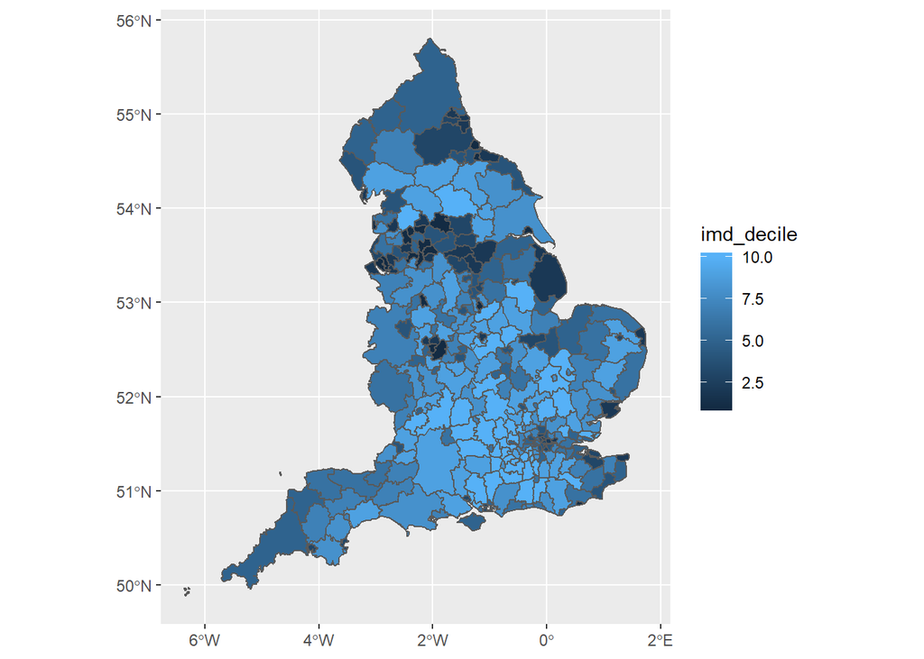

```r
raw_data$lad_shp %>%
  sf::st_as_sf() %>%
  inner_join(lad_data, by = c("LAD19CD" = "lad")) %>%
  ggplot() +
  geom_sf(aes(fill = imd_decile))
```

## Scene 2

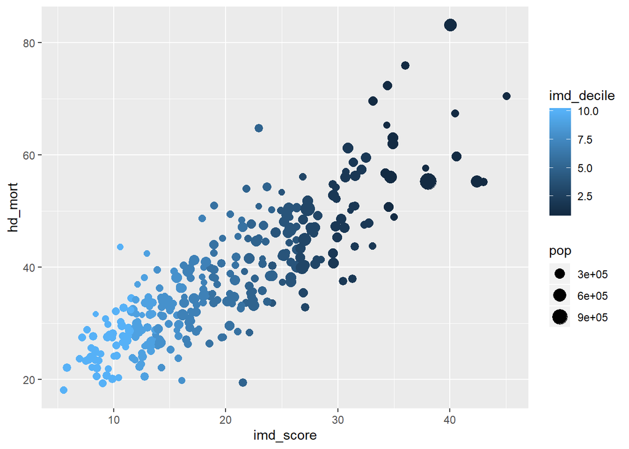

```r
ggplot(lad_data, aes(imd_score, hd_mort, col = imd_decile, size = pop)) +
  geom_point()
```

## Scene 3

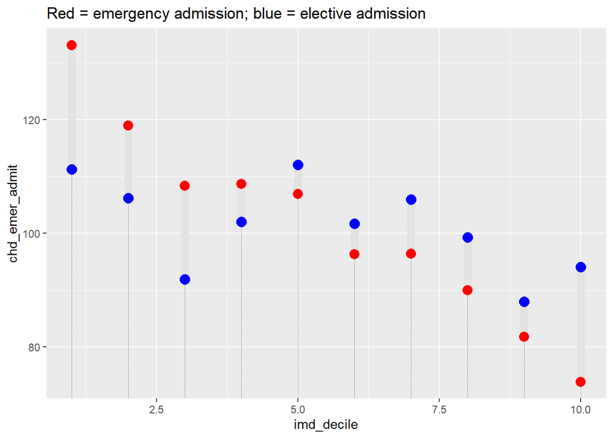

```r
ggplot(decile_data, aes(y = imd_decile, x = chd_emer_admit, xend = chd_elec_admit)) +
  ggalt::geom_dumbbell(size=3, color="#e3e2e1",
                       colour_x = "red", colour_xend = "blue",
                       dot_guide=TRUE, dot_guide_size=0.25) +
  ggtitle("Red = emergency admission; blue = elective admission") +
  coord_flip()
```

## Scene 4

https://www.nuffieldtrust.org.uk/news-item/are-parts-of-england-left-behind-by-the-nhs

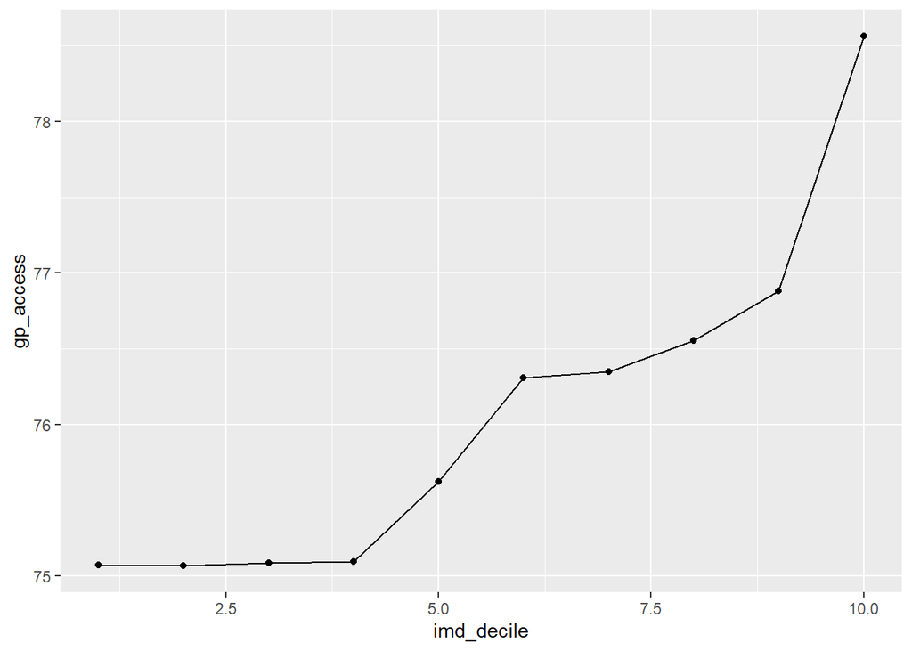

```r
ggplot(decile_data, aes(imd_decile, gp_access)) +
  geom_point() +
  geom_line()
```

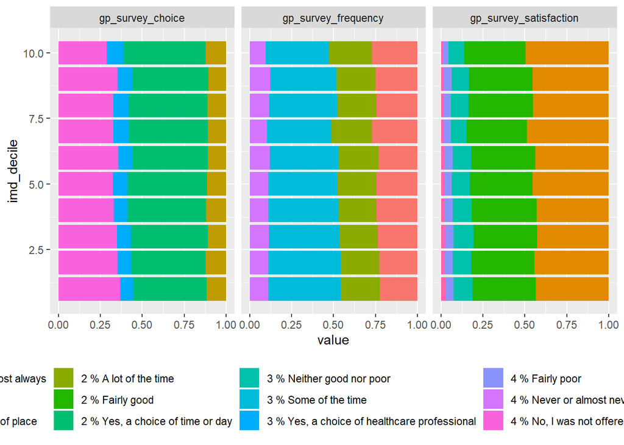

```r
decile_data %>%
  select(imd_decile, starts_with("gp_survey")) %>%
  pivot_longer(-imd_decile) %>%
  separate(name, into = c("survey", "response"), sep = "~") %>%
  ggplot(aes(imd_decile, value, fill = response)) +
  geom_col() +
  coord_flip() +
  facet_wrap(~survey, nrow = 1) +
  theme(legend.position = "bottom")
```

## Scene 5

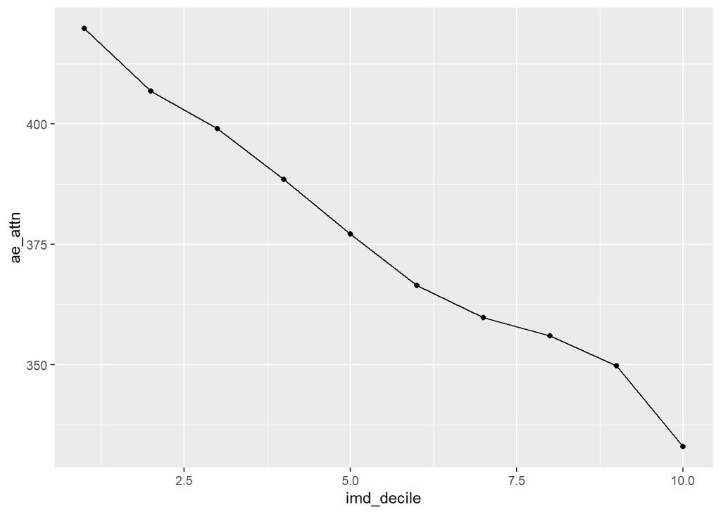

```r
ggplot(decile_data, aes(imd_decile, ae_attn)) +
  geom_point() +
  geom_line()
```

## Scene 6

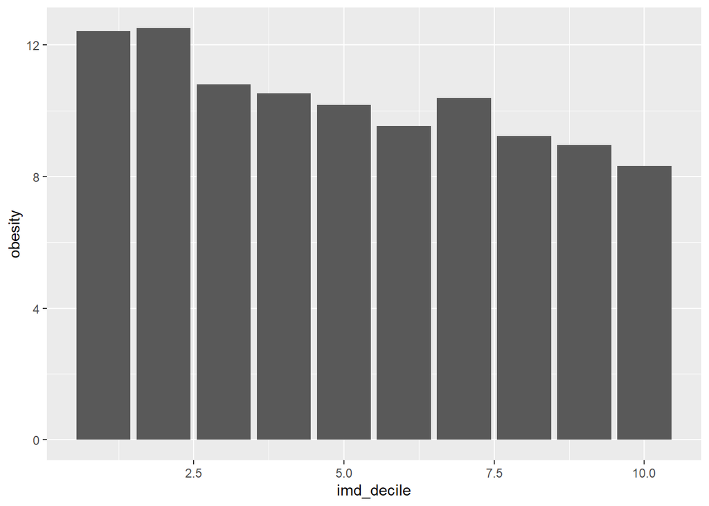

```r
ggplot(decile_data, aes(imd_decile, obesity)) +
  geom_col()
```

## Scene 7

https://societyhealth.vcu.edu/work/the-projects/why-education-matters-to-health-exploring-the-causes.html

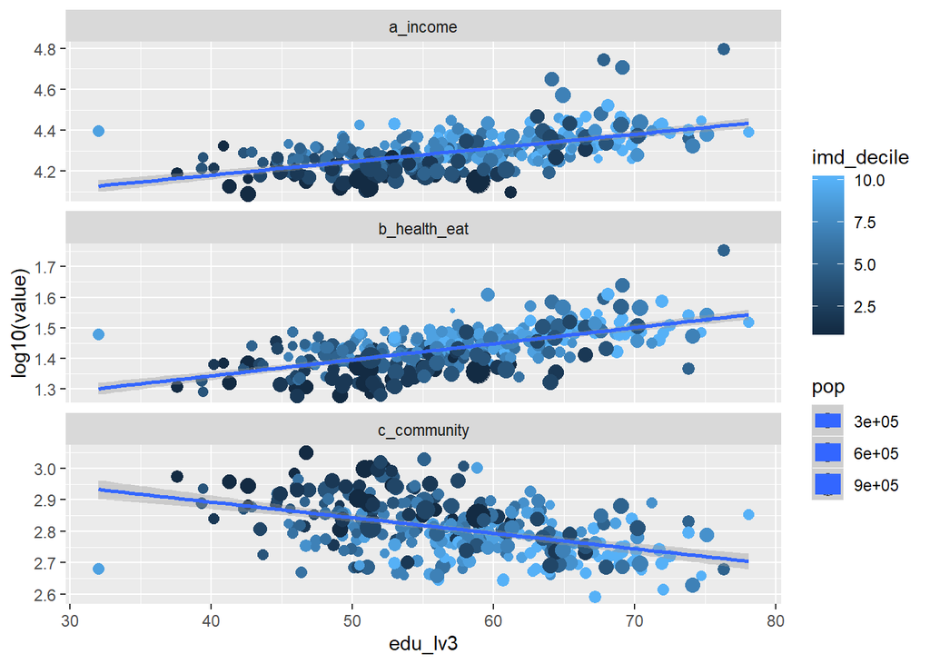

```r
lad_data %>%
  select(lad, pop, imd_decile,
         edu_lv3,
         a_income = income,
         b_health_eat = health_eat,
         c_community = community) %>%
  pivot_longer(-c(lad, pop, imd_decile, edu_lv3)) %>%
  ggplot(aes(edu_lv3, log10(value), size = pop, col = imd_decile)) +
  geom_point() +
  geom_smooth(method = "lm") +
  facet_wrap(~name, ncol = 1, scales = "free_y")
```

## Scene 8

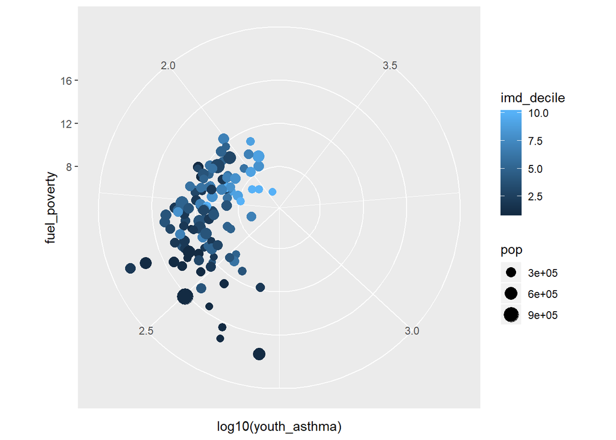

```r
ggplot(lad_data, aes(fuel_poverty, log10(youth_asthma), size = pop, col = imd_decile)) +
  geom_point() +
  coord_polar(theta = "y", direction = -1) +
  ylim(c(1.8, 3.7))
```

## Scene 9: Modelling

```r
# Consolidating all data
model_data <- lad_data %>%
  left_join(lad_data_others)

# Check NAs - youth asthma is excluded
model_data %>%
  map(is.na) %>%
  map_dbl(mean)
```

```
##            lad           ladx      imd_score            pop     imd_decile
##    0.000000000    0.000000000    0.000000000    0.000000000    0.000000000
##        hd_mort        edu_lv3         income     health_eat      community
##    0.025236593    0.018927445    0.015772871    0.000000000    0.022082019
##   fuel_poverty   youth_asthma chd_emer_admit chd_elec_admit      gp_access
##    0.034700315    0.618296530    0.000000000    0.000000000    0.104100946
##        ae_attn        obesity
##    0.003154574    0.085173502
```

```r
model_data2 <- model_data %>%
  select(-youth_asthma) %>%
  na.omit()

lad_in_trainset <- model_data2 %>%
  split(.$imd_decile) %>%
  map(function(df) {
    df2 <- df %>%
      filter(!ladx %in% c("Blackpool", "Hart"))
    sample_size <- round(nrow(df) * 0.8)
    sample_n(df2, size = sample_size, weight = pop)
  }) %>%
  bind_rows() %>%
  .[["lad"]]

model_data3 <- model_data2 %>%
  mutate(chd_emer_elec_ratio = chd_emer_admit / chd_elec_admit) %>%
  # Emergency/elective admissions were combined to one
  select(-ladx, -imd_score, -imd_decile, -chd_emer_admit, -chd_elec_admit) %>%
  mutate(test = !lad %in% lad_in_trainset)

write_csv(model_data3, "model_data.csv")
```

```python
import numpy as np
import pandas as pd
from sklearn.preprocessing import StandardScaler
from keras.models import Sequential
from keras.layers import Dense
import shap; shap.initjs()

np.random.seed(123)

model_data = r.model_data3
# model_data = pd.read_csv('model_data.csv')

train_set = model_data[model_data['test'] == False]
test_set = model_data[model_data['test'] == True]

X_train = train_set.drop(['lad', 'pop', 'hd_mort', 'test'], axis=1).to_numpy()
X_test = test_set.drop(['lad', 'pop', 'hd_mort', 'test'], axis=1).to_numpy()
y_train = train_set['hd_mort'].values.ravel()
y_test = test_set['hd_mort'].values.ravel()
sample_weight_train = train_set['pop'].values.ravel()

scaler = StandardScaler()
scaler.fit(X_train)
X_train_scaled = scaler.transform(X_train)
X_test_scaled = scaler.transform(X_test)

model = Sequential()
model.add(Dense(10, activation='relu', input_dim=X_train_scaled.shape[1]))
model.add(Dense(10, activation='relu'))
model.add(Dense(10, activation='relu'))
model.add(Dense(10, activation='relu'))
model.add(Dense(1))
model.compile(optimizer='adam', loss='mean_squared_error')
model.fit(X_train_scaled, y_train, batch_size=80, epochs=150, sample_weight=sample_weight_train)

predicted = model.predict(X_test_scaled)
summary = pd.DataFrame({'lad': test_set['lad'].values.ravel(),
                        'actual': y_test,
                        'predicted': predicted.ravel()})

explainer_shap = shap.DeepExplainer(model=model, data=X_train_scaled)
shap_values = explainer_shap.shap_values(X=X_test_scaled, ranked_outputs=True)

lad_list = test_set['lad'].values
for i in list(range(0, test_set.shape[0])):
    if lad_list[i]=='E06000009':
        i_Blackpool = i
        print('E06000009 Blackpool:', i_Blackpool)
    if lad_list[i]=='E07000089':
        i_Hart = i
        print('E07000089 Hart:', i_Hart)

E06000009_df = pd.DataFrame({'feature_names': feature_names, 'shap': shap_values[0][0][i_Blackpool]})
E06000009_df['lad'] = 'E06000009'
E06000009_df['predicted'] = predicted[i_Blackpool][0]

E07000089_df = pd.DataFrame({'feature_names': feature_names, 'shap': shap_values[0][0][i_Hart]})
E07000089_df['lad'] = 'E07000089'
E07000089_df['predicted'] = predicted[i_Hart][0]

result_df = pd.concat([E06000009_df, E07000089_df], axis=0)
result_df['base_value'] = explainer_shap.expected_value[0]

result_df.to_csv('nn_shap_value.csv')
```

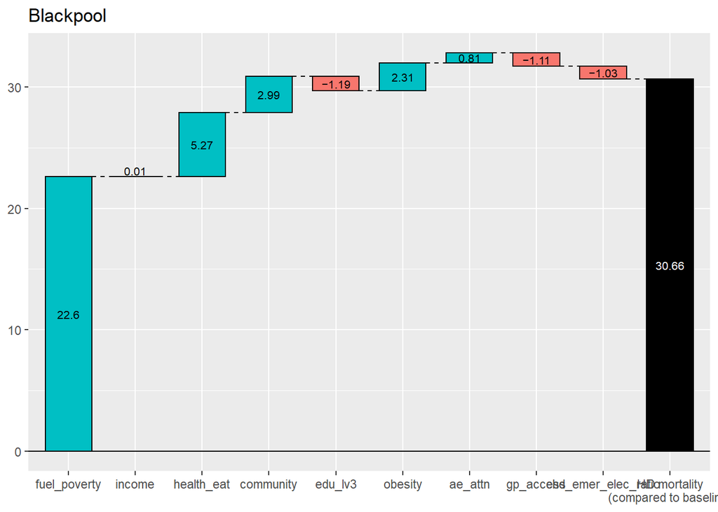

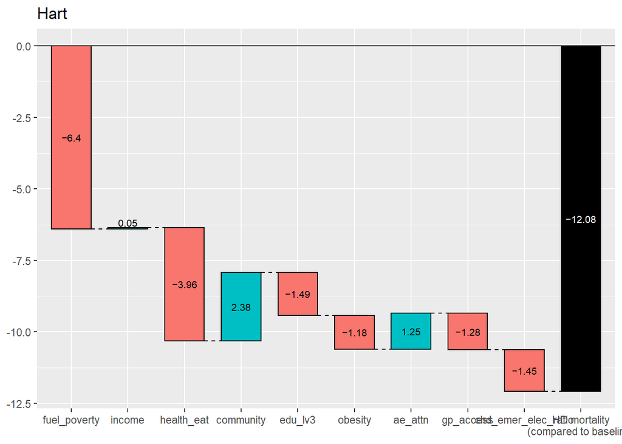

```r
# nn_shap <- read_csv("nn_shap_value.csv")
nn_shap <- read_csv("nn_shap_value.csv")

modelled_data <- nn_shap %>%
  group_by(lad) %>%
  mutate(
    diff = predicted - base_value,
    shap_pc = shap / sum(shap),
    effect_normalised = diff * shap_pc
  ) %>%
  ungroup() %>%
  left_join(hd_mort) %>%
  select(lad, feature_names, effect_normalised, base_value, predicted, actual = hd_mort) %>%
  mutate(feature_names = factor(feature_names, levels = c(
    "fuel_poverty", "income", "health_eat", "community", "edu_lv3",
    "obesity", "ae_attn", "gp_access", "chd_emer_elec_ratio")
  )) %>%
  arrange(lad, feature_names)

modelled_data %>%
  split(.$lad) %>%
  map(function(df) {
    p <- waterfalls::waterfall(values = round(df$effect_normalised, 2),
                               labels = as.character(df$feature_names),
                               calc_total = TRUE,
                               total_axis_text = "HD mortality\n(compared to baseline)")
    ladx <- imd_lad %>%
      filter(lad == unique(df$lad)) %>%
      .$ladx
    p + ggtitle(ladx)
  })
```

## Scene 10

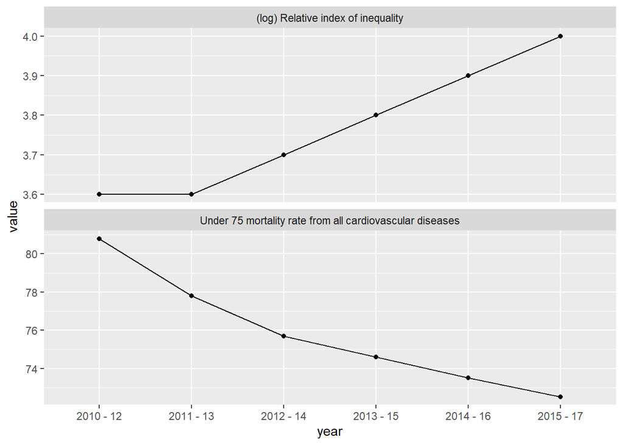

```r
inequlity %>%
  ggplot(aes(year, value, group = 1)) +
  geom_point() +
  geom_line() +
  facet_wrap(~measure, scales = "free_y", ncol = 1)
```

## Scene 11

```r
yll %>%
  filter(imd_decile %in% c(NA, 1, 10))
```

```
## # A tibble: 3 x 3
##   region     imd_decile   yll
##   <chr>           <dbl> <dbl>
## 1 imd_decile          1  7080
## 2 imd_decile         10  3935
## 3 national           NA 54020
```

# Processing data for D3 visualisation

## Helper functions

```r
normalise <- function(x, min, max) {
  range <- max - min
  map_dbl(x, ~((.x - min) / range * 100))
}

contain_x_to_viszone <- function(x, .story_width = story_width) {
  map_dbl(x, ~(.x * (1 - .story_width) + .story_width * 100))
}
```

## Map shape

```r
uk_shp0 <- raw_data[["uk_shp"]]
lad_shp0 <- raw_data[["lad_shp"]]

crop_pc <- list(x = 0.25, y = 0.35)

standardise_coord <- function(value, x_or_y, bbox) {
  bbox_len <- bbox[x_or_y, "max"] - bbox[x_or_y, "min"]
  if (x_or_y == "y") {
    bbox[x_or_y, "max"] <- bbox[x_or_y, "min"] + bbox_len * (1 - crop_pc[[x_or_y]])
  } else if (x_or_y == "x") {
    bbox[x_or_y, "min"] <- bbox[x_or_y, "max"] - bbox_len * (1 - crop_pc[[x_or_y]])
  }
  bbox_len_cropped <- bbox[x_or_y, "max"] - bbox[x_or_y, "min"]
  (value - bbox[x_or_y, "min"]) * (100 / bbox_len_cropped)
}
output_coord_df_standardised <- function(matrix, bbox) {
  matrix %>%
    as_tibble() %>%
    mutate(
      x = standardise_coord(x, "x", bbox) * 0.5 + 50,  # For x:y ratio
      y = standardise_coord(y, "y", bbox)
    ) %>%
    mutate(x = x * 0.9, y = y * 0.9 + 5)  # For margin

}

uk_shp1 <- uk_shp0[uk_shp0$ctry18nm %in% c("Scotland", "Wales"), ] %>%
  rgeos::gSimplify(tol = 1000)
uk_shp2 <- map(uk_shp1@polygons, ~.x@Polygons) %>%
  flatten() %>%
  map(~.x@coords %>%
        output_coord_df_standardised(uk_shp0@bbox)
  )
uk_shp3 <- uk_shp2[map_dbl(uk_shp2, nrow) > 0] %>%
  map(as.list)

lad_shp1 <- lad_shp0 %>%
  sf::st_as_sf() %>%
  filter(LAD19CD %in% imd_lad$lad)

if ("lad_shp2.RDS" %in% list.files()) {
  lad_shp2 <- readRDS("lad_shp2.RDS")
} else {
  par(mfrow = c(2, 3), mar = c(0, 0, 2, 0))
  lad_shp_hex_ls <- list()
  for (i in 1:6) {
    lad_shp_hex_ls[[i]] <- geogrid::calculate_grid(
      shape = lad_shp1,
      grid_type = "hexagonal",
      seed = i
    )
    plot(lad_shp_hex_ls[[i]], main = paste("Seed", i, sep = " "))
  }
  lad_shp_grid <- lad_shp_hex_ls[[5]]

  lad_shp2 <- geogrid::assign_polygons(lad_shp1, lad_shp_grid)
  # Takes around 20 minutes
  saveRDS(lad_shp2, "lad_shp2.RDS")
}

lad_shp3 <- lad_shp2$geometry %>%
  setNames(lad_shp2$LAD19CD) %>%
  map(~as.character(.x) %>%
        str_remove_all("^c\\(|\\)$") %>%
        str_split(", ") %>%
        .[[1]] %>%
        as.numeric() %>%
        matrix(ncol = 2) %>%
        head(6) %>%
        as_tibble() %>%
        setNames(c("x", "y")) %>%
        output_coord_df_standardised(lad_shp0@bbox) %>%
        mutate(x = x - 3) %>%  # To correct slight mismatch
        as.list()) %>%
  .[lad_data$lad]
```

## LAD

```r
hexscatter_df <- lad_data %>%
  mutate(
    hd_mort_na = ifelse(is.na(hd_mort), 1, 0),
    x_from = map_dbl(lad_shp3, ~mean(.x$x)),
    y_from = map_dbl(lad_shp3, ~mean(.x$y)),
    x_to = (1 - imd_score / max(imd_score, na.rm = TRUE)) * 100 + 2,
    x_to = x_to * (1 - story_width) + story_width * 100,
    y_to = hd_mort / max(hd_mort, na.rm = TRUE) * 100 - 10,
    x_delta = x_to - x_from,
    y_delta = y_to - y_from,
    hexscatter = pmap(
      list(lad_shp3, x_delta, y_delta, hd_mort_na),
      function(h, xd, yd, na) {
        if (na == 1) {
          coord <- list(x = h$x, y = h$y)
        } else {
          coord <- list(x = h$x + xd, y = h$y + yd)
        }
        left_join(  # This is to reduce the size of hexagons
          as_tibble(coord) %>%
            gather(),
          as_tibble(coord) %>%
            summarise_all(mean) %>%
            gather(key, value_centre),
          by = "key"
        ) %>%
          mutate(
            length = value - value_centre,
            length_scaled = length * 0.8,
            value_scaled = value_centre + length_scaled
          ) %>%
          select(key, value_scaled) %>%
          split(.$key) %>%
          map("value_scaled")
      }
    )
  ) %>%
  select(lad, hd_mort_na, hexscatter)

hex_collapse <- lad_data %>%
  mutate(
    hd_mort_na = ifelse(is.na(hd_mort), 1, 0),
    imd_decile_jitter = jitter(imd_decile, amount = 0.3),
    x_from = map_dbl(hexscatter_df$hexscatter, ~mean(.x$x)),
    y_from = map_dbl(hexscatter_df$hexscatter, ~mean(.x$y)),
    x_to = story_width * 100,
    y_to = imd_decile_jitter / max(imd_decile_jitter, na.rm = TRUE) * 100,
    y_to = y_to * 0.8 + 15,
    x_delta = x_to - x_from,
    y_delta = y_to - y_from,
    hex_collapse = pmap(
      list(hexscatter_df$hexscatter, x_delta, y_delta, hd_mort_na),
      function(h, xd, yd, na) {
        if (na == 1) {
          coord <- list(x = 50, y = 50)
        } else {
          coord <- list(x = h$x + xd, y = h$y + yd)
        }
      }
    )
  ) %>%
  .[["hex_collapse"]]


lad_data_p <- lad_data %>%
  mutate(
    tooltip = paste0(
      "<b>", ladx, "</b><br><sup>Local Authority District ", lad,"</sup><br>",
      "Deprivation score: ", round(imd_score), "<br><sup>Index of Multiple Deprivation (IMD), higher is worse</sup><br>",
      "Deprivation decile group: ", imd_decile, "<br><sup>1st is most deprived and 10th is least deprived</sup>"
    ),
    tooltip2 = paste0(
      tooltip, "<br>Premature death rate (mortality rate) from heart disease: ", round(hd_mort),
      "<br><sup>Rate of deaths at age under 75 years</sup>"
    )
  ) %>%
  select(lad, ladx, imd_decile, tooltip, tooltip2) %>%
  mutate(
    hexmap = lad_shp3,
    hex_collapse = hex_collapse
  ) %>%
  left_join(hexscatter_df)
```

## LAD (for scene 7 onward)

```r
# summary(lad_data$edu_lv3)
edu_range <- c(min = 30, max = 80)
# summary(lad_data$income)
# summary(log10(lad_data$income))
# summary(lad_data$health_eat)
# summary(log10(lad_data$health_eat))
# summary(lad_data$community)
# summary(log10(lad_data$community))

lad_is_na <- lad_data %>%
  select(edu_lv3, income, health_eat, community) %>%
  mutate_all(is.na) %>%
  rowSums()

scene7_layout <- list(top_margin = 0.08, bottom_margin = 0.07, between_pad = 0.01)
scene7_layout[["p_height"]] <- (
  1 - scene7_layout$top_margin - scene7_layout$bottom_margin -
    scene7_layout$between_pad * 2
) / 3
scene7_layout[["p3_start"]] <- scene7_layout$bottom_margin
scene7_layout[["p3_end"]] <- scene7_layout$p3_start + scene7_layout$p_height
scene7_layout[["p3_mid"]] <- (scene7_layout[["p3_start"]] +
                              scene7_layout[["p3_end"]]) / 2
scene7_layout[["p2_start"]] <- scene7_layout$p3_end + scene7_layout$between_pad
scene7_layout[["p2_end"]] <- scene7_layout$p2_start + scene7_layout$p_height
scene7_layout[["p2_mid"]] <- (scene7_layout[["p2_start"]] +
                              scene7_layout[["p2_end"]]) / 2
scene7_layout[["p1_start"]] <- scene7_layout$p2_end + scene7_layout$between_pad
scene7_layout[["p1_end"]] <- scene7_layout$p1_start + scene7_layout$p_height
scene7_layout[["p1_mid"]] <- (scene7_layout[["p1_start"]] +
                              scene7_layout[["p1_end"]]) / 2

lad_data_p2 <- lad_data[lad_is_na == 0, ] %>%
  select(lad, ladx, pop, imd_decile, edu_lv3, income, health_eat, community) %>%
  mutate_at(vars(income, health_eat, community), list(log10)) %>%
  # Normalising
  mutate(
    edu_lv3 = normalise(edu_lv3, edu_range[["min"]], edu_range[["max"]]),
    pop = normalise(pop, min(pop), max(pop)),
    pop = 1 + pop / 100
  ) %>%
  mutate_at(vars(income, health_eat, community), list(function(x) {
    lower <- floor(min(x) * 10) / 10
    upper <- ceiling(max(x) * 10) / 10
    normalise(x, lower, upper)
  })) %>%
  # Converse "community" variable
  mutate(community = 100 - community) %>%
  # Transform for three sections
  mutate_at(vars(income, health_eat, community), list(~. * scene7_layout$p_height)) %>%
  mutate(
    y1 = income + scene7_layout$p1_start * 100,
    y2 = health_eat + scene7_layout$p2_start * 100,
    y3 = community + scene7_layout$p3_start * 100,
  ) %>%
  select(lad, ladx, pop, imd_decile, x = edu_lv3, y1, y2, y3) %>%
  pivot_longer(c(y1, y2, y3), values_to = "y") %>%
  left_join(
    lad_data %>%
      select(lad, edu_lv3, income, health_eat, community)
  ) %>%
  mutate(
    tooltip1 = paste0(
      "<b>", ladx, "</b><br><sup>Local Authority District ", lad,"</sup><br><u>",
      round(edu_lv3, 1), "%</u> attained Level 3 at 19<br>"
    ),
    tooltip2 = case_when(
      name == "y1" ~ paste0("Gross Disposable Household Income per head is <u>&pound;",
                            prettyNum(round(income), big.mark = ","), "</u>"),
      name == "y2" ~ paste0("<u>", round(health_eat, 1),
                            "%</u> of adults have healthy eating habits"),
      name == "y3" ~ paste0("<u>", prettyNum(round(community), big.mark = ","),
                            "</u> admissions for alcohol-related conditions per 100,000 population (age standardised)")
    ),
    tooltip = paste0(tooltip1, tooltip2, "<br><sup>The vertical axis is log scale</sup>")
  ) %>%
  select(lad, ladx, pop, imd_decile, x, name, y, tooltip) %>%
  mutate(
    y_start = case_when(
      name == "y1" ~ scene7_layout[["p1_mid"]],
      name == "y2" ~ scene7_layout[["p2_mid"]],
      name == "y3" ~ scene7_layout[["p3_mid"]]
    ),
    y_start = jitter(y_start * 100, amount = 1),
    x = contain_x_to_viszone(x * 0.6 + 20),
    stroke = ifelse(lad %in% c("E07000089", "E06000009"), "white", "none")
  )

# summary(lad_data$fuel_poverty)
r_range <- c(min = 3, max = 19.5)
# summary(log10(lad_data$youth_asthma))

process_circle <- function(df) {
  df %>%
    mutate(
      r = normalise(fuel_poverty, r_range[["min"]], r_range[["max"]]) * 0.5,
      angle = log10(youth_asthma),
      angle = normalise(angle, 1.8, 2.8),
      more_than_half = angle > 50,
      angle2 = ifelse(!more_than_half, angle, 100 - angle),
      t = tan(angle2 / 100 * pi),
      y_raw = sqrt(r^2 / (t^2 + 1)),
      x_diff = y_raw * t,
      y = ifelse(!more_than_half, y_raw, -y_raw) + 50
    )
}

lad_data_p3 <- lad_data %>%
  group_by(imd_decile) %>%
  mutate(
    youth_asthma_imputed = weighted.mean(youth_asthma, pop, na.rm = TRUE),
    youth_asthma = ifelse(lad == "E07000089", youth_asthma_imputed, youth_asthma)
  ) %>%
  ungroup() %>%
  filter(!is.na(youth_asthma) & !is.na(fuel_poverty)) %>%
  process_circle() %>%
  mutate(
    tooltip = paste0(
      "<b>", ladx, "</b><br><sup>Local Authority District ", lad,"</sup><br><u>",
      round(fuel_poverty, 1), "%</u> of households are fuel poor<br><u>",
      prettyNum(round(youth_asthma), big.mark = ","),
      "</u> asthma admissions for under 19 years per 100,000 population"
    ),
    pop = normalise(pop, min(pop), max(pop)),
    pop = 1 + pop / 100,
    point = case_when(
      lad == "E07000089" ~ "a",
      lad == "E06000009" ~ "b"
    )
  ) %>%
  select(lad, point, x_diff, y, imd_decile, tooltip, pop)

scene8_radius <- tibble(youth_asthma = 1:5 * 100, fuel_poverty = 20) %>%
  process_circle() %>%
  select(youth_asthma, x_diff, y)
scene8_circum <- tibble(youth_asthma = 5 * 100, fuel_poverty = 1:4 * 5) %>%
  process_circle() %>%
  select(fuel_poverty, r)
```

## Modelled data

```r
scene9_layout <- c(top = 0.1, bottom = 0.05, pad = 0.05)

modelled_data_wip <- modelled_data %>%
  group_by(lad) %>%
  bind_rows(., summarise_at(., vars(effect_normalised), list(sum))) %>%
  ungroup() %>%
  # mutate(denominator = max(abs(effect_normalised))) %>%
  split(.$lad) %>%
  map(function(df) {
    # unique(df$predicted)
    # unique(df$actual)
    # unique(df$base_value)
    df %>%
      mutate(
        h = effect_normalised,
        feature = case_when(
          feature_names == "fuel_poverty" ~ "Fuel poverty",
          feature_names == "income" ~ "Household income",
          feature_names == "health_eat" ~ "Healthy eating",
          feature_names == "community" ~ "Alcohol-related admissions",
          feature_names == "edu_lv3" ~ "Education",
          feature_names == "obesity" ~ "Obesity",
          feature_names == "ae_attn" ~ "A&E attendance",
          feature_names == "gp_access" ~ "Access to GP",
          feature_names == "chd_emer_elec_ratio" ~ "Emergency admission",
          TRUE ~ "<b>Total</b>"
        ),
        end = cumsum(h),
        start = end - h,
        end = ifelse(row_number() == nrow(.), lag(end, 1), end),
        start = ifelse(row_number() == nrow(.), 0, start)
      ) %>%
      select(feature_names, feature, h, start, end)
  }) %>%
  .[c("E06000009", "E07000089")] %>%
  setNames(c("p1", "p2"))

scene9_height_range <- modelled_data_wip %>%
  map(pivot_longer, -c(feature, feature_names)) %>%
  bind_rows() %>%
  .$value %>%
  range(na.rm = TRUE) %>%
  setNames(c("p2", "p1")) %>%
  .[c("p1", "p2")]

scene9_height_ratio <- ((1 - sum(scene9_layout)) * abs(scene9_height_range) / sum(abs(scene9_height_range))) %>%
  .[c("p1", "p2")]

modelled_data_wip2 <- pmap(
  list(modelled_data_wip, scene9_height_range, scene9_height_ratio),
  function(d, range, ratio) {
    d2 <- d %>%
      mutate_at(vars(h, start, end), list(~normalise(., 0, abs(range)) * ratio))
    offset <- min(pivot_longer(d2, -c(feature, feature_names, h))$value, na.rm = TRUE)
    d2 %>%
      mutate_at(vars(start, end), list(~. - offset))
  }) %>%
  map(mutate, feature_names = as.character(feature_names)) %>%
  map(mutate, feature_names = ifelse(is.na(feature_names), "hd_mort", feature_names))

scene9_layout[["p2_axis"]] <- scene9_layout[["bottom"]] + scene9_height_ratio[["p2"]]
scene9_layout[["p1_axis"]] <- scene9_layout[["p2_axis"]] +
  scene9_layout[["pad"]]
scene9_layout <- scene9_layout %>%
  append(list(axis_label = tibble(feature = modelled_data_wip2$p1$feature)))

percentile_worse_best <- function(worse_higher = TRUE) {
  ifelse(worse_higher,
         "% percentile in England, where 100% is worst and 0% is best)",
         "% percentile in England, where 0% is worst and 100% is best)")
}

model_tooltip_x <- model_data %>%
  mutate(chd_emer_elec_ratio = chd_emer_admit / chd_elec_admit) %>%
  mutate_if(is.numeric, list(pc = ~percent_rank(.) * 100)) %>%
  filter(lad %in% modelled_data$lad) %>%
  select(
    lad, ladx,
    levels(modelled_data$feature_names),
    paste0(levels(modelled_data$feature_names), "_pc")
  ) %>%
  pivot_longer(-c(lad, ladx)) %>%
  mutate(
    cat = ifelse(str_detect(name, "_pc"), "pc", "value"),
    name = str_remove(name, "_pc")
  ) %>%
  pivot_wider(names_from = "cat", values_from = "value") %>%
  rename(feature_names = name) %>%
  left_join(modelled_data) %>%
  mutate(
    tooltip = case_when(
      feature_names == "fuel_poverty" ~
        paste0("fuel poverty ", round(value, 1), "%<br>(",
               round(pc), percentile_worse_best()),
      feature_names == "income" ~
        paste0("household income &pound;", prettyNum(round(value), big.mark = ","), "<br>(",
               round(pc), percentile_worse_best(FALSE)),
      feature_names == "health_eat" ~
        paste0("proportion of healthy eating adults ", round(value, 1), "%<br>(",
               round(pc), percentile_worse_best(FALSE)),
      feature_names == "community" ~
        paste0("alcohol-related admissions ", prettyNum(round(value), big.mark = ","), "<br>(",
               round(pc), percentile_worse_best()),
      feature_names == "edu_lv3" ~
        paste0("proportion of attainment of lv 3 at 19 ", round(value, 1), "%<br>(",
               round(pc), percentile_worse_best(FALSE)),
      feature_names == "obesity" ~
        paste0("obesity prevalence ", round(value, 1), "%<br>(",
               round(pc), percentile_worse_best()),
      feature_names == "ae_attn" ~
        paste0("A&E attendance rate ", prettyNum(round(value), big.mark = ","), "<br>(",
               round(pc), percentile_worse_best()),
      feature_names == "gp_access" ~
        paste0("number GPs per 100,000 patients ", round(value, 1), "<br>(",
               round(pc), percentile_worse_best(FALSE)),
      feature_names == "chd_emer_elec_ratio" ~
        paste0("emergency:planned ratio of CHD admissions ", round(value, 2), ":1<br>(",
               round(pc), percentile_worse_best(FALSE)),
    ),
    tooltip = paste0(ladx, "&rsquo;s ", tooltip, "<br>",
                     ifelse(effect_normalised > 0, "added ", "reduced "),
                     "<u>", abs(round(effect_normalised, 1)), "</u>",
                     ifelse(effect_normalised > 0, " to ", " from "),
                     "simulated death rate (mortality rate)")
  ) %>%
  select(lad, feature_names, tooltip)

model_tooltip_y <- modelled_data %>%
  select(lad, base_value, predicted, actual) %>%
  unique() %>%
  left_join(imd_lad %>% select(lad, ladx)) %>%
  mutate_if(is.numeric, list(~round(., 1))) %>%
  mutate(
    tooltip = paste0(
      "Factors mentioned on left plus base rate of ", base_value,
      " result in ", ladx,
      "&rsquo;s simulated death rate (mortality rate) of <u>", predicted,
      "</u> (actual is ", actual, ")"),
    feature_names = "hd_mort"
  ) %>%
  select(lad, feature_names, tooltip)

model_tooltip <- bind_rows(model_tooltip_x, model_tooltip_y) %>%
  split(.$lad)

modelled_data_p <- list(
  p1 = modelled_data_wip2$p1 %>%
    mutate_at(vars(start, end),
              list(~. + scene9_layout[["p1_axis"]] * 100)) %>%
    left_join(model_tooltip$E06000009),
  p2 = modelled_data_wip2$p2 %>%
    mutate_at(vars(start, end),
              list(~. + scene9_layout[["bottom"]] * 100)) %>%
    left_join(model_tooltip$E07000089)
) %>%
  map(mutate, imd_decile = case_when(
    feature_names != "hd_mort" & h > 0 ~ 2,
    feature_names != "hd_mort" & h < 0 ~ 9,
    feature_names == "hd_mort" & h > 0 ~ 1,
    feature_names == "hd_mort" & h < 0 ~ 10
  ))
```

## Others

```r
inequlity_data_p <- inequlity %>%
  mutate(
    tooltip = case_when(
      data == "hd_mort_eng" ~ "Premature death rate (mortality rate, under 75)<br>from heart disease in England",
      data == "inequality_index" ~ "Relative index of inequality (log scale)"
    ),
    tooltip = paste0(tooltip, ",<br>during ", year, "<br>: <u>", round(value, 1), "</u>")
  ) %>%
  split(.$data) %>%
  map(mutate, x = row_number()) %>%
  map(mutate, x = x / max(x) * 80 + 10) %>%
  modify_at(
    "hd_mort_eng",
    ~.x %>%
      mutate(
        value = normalise(value, 50, 100),
        x = x / 2 * 0.9 + 5,
        imd_decile = 9
      )
  ) %>%
  modify_at(
    "inequality_index",
    ~.x %>%
      mutate(
        value = normalise(value, 3, 5),
        x = x / 2 * 0.9 + 55,
        imd_decile = 2,
        measure = "Relative index of inequality (log)"
      )
  ) %>%
  map(mutate, value = value * 0.75 + 5)

yll_summ <- yll %>%
  filter(imd_decile %in% c(NA, 1, 10)) %>%
  mutate(
    region = ifelse(is.na(imd_decile), region, paste0(region, imd_decile)),
    yll = prettyNum(yll, big.mark = ",")
  ) %>%
  (function(x) x$yll %>% setNames(x$region)) %>%
  as.list()
```

## Location of A & B

```r
ab_loc <- lad_data_p %>%
  mutate(point = case_when(
    ladx == "Hart" ~ "a",
    ladx == "Blackpool" ~ "b"
  )) %>%
  filter(!is.na(point)) %>%
  mutate(
    s1_x = map_dbl(hexmap, ~mean(.x$x)), s1_y = map_dbl(hexmap, ~mean(.x$y)),
    s2_x = map_dbl(hexscatter, ~mean(.x$x)), s2_y = map_dbl(hexscatter, ~mean(.x$y))
  ) %>%
  select(point, ends_with("_x"), ends_with("_y")) %>%
  pivot_longer(-point) %>%
  separate(name, into = c("scene", "name"), sep = "_") %>%
  pivot_wider() %>%
  split(.$scene)
ab_loc[["s3"]] <- decile_data_p %>%
  mutate(point = case_when(
    imd_decile == 10 ~ "a",
    imd_decile == 1 ~ "b"
  )) %>%
  filter(!is.na(point)) %>%
  mutate(
    x = story_width * 100,
    y = decile_y
  )
ab_loc[["s7"]] <- lad_data_p2 %>%
  select(lad, x) %>%
  unique() %>%
  mutate(point = case_when(
    lad == "E07000089" ~ "a",
    lad == "E06000009" ~ "b"
  )) %>%
  filter(!is.na(point)) %>%
  mutate(y = scene7_layout$p3_start * 100)
ab_loc[["s8"]] <- lad_data_p3 %>%
  filter(!is.na(point)) %>%
  select(point, x_diff, y)
ab_loc[["s9"]] <- tibble(
  point = c("b", "a"),
  x = 21,
  y = c(scene9_layout$p1_axis, scene9_layout$p2_axis) * 100 - 0.3
)
```

## Save as JSON

```r
list(
  uk_shp = uk_shp3,

  lad = lad_data_p,

  decile = decile_data_p,
  gp_x = decile_data_p$gp_x, gp_grad = decile_data_p$gp_grad,
  ae_x = decile_data_p$ae_x, ae_grad = decile_data_p$ae_grad,
  decile_y = decile_data_p$decile_y,

  scene7_layout = map(scene7_layout, ~.x * 100),

  lad2 = lad_data_p2,
  lad3 = lad_data_p3,
  scene8_radius = scene8_radius, scene8_circum = scene8_circum,
  scene8_inner = scene8_circum$r[1],

  model = modelled_data_p,
  scene9_layout = map_if(scene9_layout, is.numeric, ~.x * 100),

  inequlity = inequlity_data_p,
  inequlity_path_x = inequlity_data_p %>% map("x"),
  inequlity_path_y = inequlity_data_p %>% map("value"),
  inequlity_axis = inequlity_data_p %>%
    map("measure") %>%
    map_chr(unique),

  yll = yll_summ,

  ab_loc = ab_loc %>%
    map(~.x %>%
          split(.$point) %>%
          map(select, starts_with("x"), y) %>%
          map(as.list))
) %>%
  jsonlite::toJSON() %>%
  write("js/data.json")
```